# Do Reverse Janzen-Connell Effects Reduce Species Diversity? - ScienceDirect

## Outline

1. Host-Specific Natural Enemies Increase Community Diversity
2. Can Host-Specific Mutualists Decrease Community Diversity?
3. Evidence for Reverse Janzen-Connell Effects
4. Future Research Directions
5. Concluding Remarks
6. Declaration of Interests
7. References
8. Glossary

## Figures (2)

[figure not shown]

[figure not shown]

[figure not shown]

## Trends in Ecology & Evolution

Available online 27 February 2021

[In Press, Corrected Proof](https://www.sciencedirect.com/science/journal/aip/01695347)

# Forum Do Reverse Janzen-Connell Effects Reduce Species Diversity?

[ShafiaZahra<sup>1</sup><sup>2</sup>](https://www.sciencedirect.com/science/article/pii/S0169534721000367?casa_token=rXvvDGtFHsgAAAAA:86DBmWrnpc6SShrAub2VUZRFEp4GSWS1WZ_9fIyBxCmHIrcgvsYgV1_HWsoA5l9xcVKBnF3aaA#!)[VojtechNovotny<sup>1</sup><sup>2</sup>](https://www.sciencedirect.com/science/article/pii/S0169534721000367?casa_token=rXvvDGtFHsgAAAAA:86DBmWrnpc6SShrAub2VUZRFEp4GSWS1WZ_9fIyBxCmHIrcgvsYgV1_HWsoA5l9xcVKBnF3aaA#!)[Tom M.Fayle<sup>1</sup>](https://www.sciencedirect.com/science/article/pii/S0169534721000367?casa_token=rXvvDGtFHsgAAAAA:86DBmWrnpc6SShrAub2VUZRFEp4GSWS1WZ_9fIyBxCmHIrcgvsYgV1_HWsoA5l9xcVKBnF3aaA#!)

https://doi.org/10.1016/j.tree.2021.02.002[Get rights and content](https://s100.copyright.com/AppDispatchServlet?publisherName=ELS&contentID=S0169534721000367&orderBeanReset=true)

Host-specific natural enemies limit the abundance of common species. This can increase host community diversity, since no single species dominates, and is known as the ‘Janzen-Connell effect.’ Evidence is now accumulating that host-specific mutualists can increase abundances of particular host species, hence reducing community diversity, comprising a ‘reverse Janzen-Connell effect.’

## Host-Specific Natural Enemies Increase Community Diversity

Interactions between species in networks can scale up to influence overall community structure. One well-explored example of this is the **Janzen-Connell effect** (see Glossary) whereby host-specific **natural enemies** reduce the fitness of **host** offspring close to parent host individuals. This prevents any single host species from dominating the community, hence maintaining species diversity (Figure 1A) [1]. Janzen-Connell effects have been invoked mainly to explain the high diversity of tropical tree communities. However, the same mechanism also operates in communities of temperate trees, grassland, and coral reefs. European grasses attain higher biomass if sowed on soil where **conspecific** plants are absent, which indicates the importance of specialized soil pathogens in mediating Janzen-Connell effects [2]. Furthermore, due to host-specific microbial pathogens, the mortality of coral larvae and polyps in the Caribbean is higher in water that has been in contact with conspecifics than in water that has been sterilized or never in contact with conspecifics [3].

[figure not shown]

Figure 1. The Mechanism by Which Standard and Reverse Janzen-Connell Effects Operate.

(A) Spillover of plant natural enemies (e.g., herbivores) creates a gap in which conspecific offspring are less likely to survive, hence promoting coexistence with other species. (B) Where spillover is of plant mutualists [e.g., ectomycorrhizal (EM) fungi], no gap is created, and instead nearby conspecifics are more likely to survive, resulting in the focal species outcompeting others. In the most extreme case, this may result in a pure stand of the monodominant species. (C) For standard Janzen-Connell effects, natural enemy spillover combined with dispersal limitation leads to a unimodal recruitment curve for the focal species. (D) For reverse Janzen-Connell effects, spillover of mutualists and dispersal limitation act in the same direction, resulting in high recruitment close to parent plants but low recruitment at greater distances. (E) The recruitment curve for the reverse Janzen-Connell (J-C) effect is expected to show a monotonic decrease, in contrast to the unimodal recruitment curve expected for the standard Janzen-Connell effect. Source of tree images: [www.freepik.com](http://www.freepik.com/).

## Can Host-Specific Mutualists Decrease Community Diversity?

There is now increasing interest in the impacts of mutualists on overall community structure. If host-specific natural enemies increase diversity, then we would expect host-specific mutualists to decrease diversity via a **reverse Janzen-Connell effect** in which the fitness of nearby conspecific host individuals is increased due to spatially constrained influence of host-specific mutualists [4] (Figure 1B). We include in this definition positive density or distance dependence that is mediated indirectly by mutualists, such as via positive abiotic soil feedback. However, we exclude other abiotic drivers that weaken standard Janzen-Connell effects, such as increased insolation in more open areas due to treefalls, which can negatively affect host natural enemies. Reverse Janzen-Connell effects were first proposed as an explanation for low diversity of trees in some tropical forests, with some species being **monodominant** [5].

It is illustrative to contrast the predictions made by the reverse Janzen-Connell hypothesis with those expected from the standard effect (Figure 1C,D). Assuming that dispersal kernels of hosts are similar, then recruitment for standard Janzen-Connell effects is expected to be greatest at an intermediate distance from the parent individual, where natural enemies have less effect but offspring can still disperse. In contrast, if host mutualists mediate reverse Janzen-Connell effects, then recruitment should be greatest close to parent individuals (Figure 1E), although in most cases this will be limited at the shortest distances by conspecific competition. Interestingly, this indicates that the potential for conspecific competition will be greater in systems dominated by reverse Janzen-Connell effects than in those dominated by standard Janzen-Connell effects. In this context, evolution of host-specific mutualisms is a mechanism for increasing tolerance of conspecific competition. In terms of expected spatial patterns, the standard Janzen-Connell hypothesis predicts low conspecific spatial clustering, since conspecific pairwise distances are limited by host-specific natural enemies. The reverse Janzen-Connell hypothesis predicts greater conspecific clustering, since offspring close to adult hosts have greater fitness. Variation in the dispersal abilities of hosts, natural enemies, and mutualists will also influence the dynamic distribution of the host species. Consequent weakening of conspecific negative density dependence is predicted to reduce overall community diversity. However, the degree to which this occurs depends on the relative strength of the Janzen-Connell and reverse Janzen-Connell effects on overall host density dependence, making the reverse effects harder to detect. Hence, there is a need to put reverse Janzen-Connell effects into the context of the multiple other drivers of conspecific density dependence.

## Future Research Directions

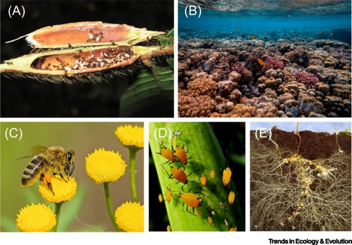

Figure 2. Ecosystems in Which Reverse Janzen-Connell Effects Are Potentially Important.

Understanding both standard and reverse Janzen-Connell effects has potential applications in agriculture, such as optimizing spacing of plants to prevent natural enemy spillover, but to maximize spillover of mutualists. Furthermore, exploration of reverse Janzen-Connell effects as potential drivers of invasion via enhanced mutualism would allow better management strategies to reduce negative impacts of non-native species. Finally, horizontal but spatially limited sharing of mutualists could be the first evolutionary step along the path to vertical transmission of mutualistic symbionts. Hence, exploration of the phylogenetic patterns of reverse Janzen-Connell effects and vertical mutualistic symbiont transmission in the context of mutualistic interactions more generally could be rewarding.

## Concluding Remarks

Although reverse Janzen-Connell effects will not always drive single species or clades to entirely dominate a community, they are nonetheless potentially widespread and important drivers of community structure. Hence, quantifying these effects in the context of other drivers of density dependence will allow a better overall understanding of the maintenance of diversity in biological communities.

## Declaration of Interests

There are no interests to declare.

## References

**1.**

L.S. Comita, *et al.*

**Testing predictions of the Janzen–Connell hypothesis: a meta-analysis of experimental evidence for distance-and density-dependent seed and seedling survival**

J. Ecol., 102 (2014), pp. 845-856

[CrossRef](https://doi.org/10.1111/1365-2745.12232)[View Record in Scopus](https://www.scopus.com/inward/record.url?eid=2-s2.0-84902994474&partnerID=10&rel=R3.0.0)Google Scholar

**2.**

J.S. Petermann, *et al.*

**Janzen-Connell effects are widespread and strong enough to maintain diversity in grasslands**

Ecology, 89 (2008), pp. 2399-2406

[CrossRef](https://doi.org/10.1890/07-2056.1)[View Record in Scopus](https://www.scopus.com/inward/record.url?eid=2-s2.0-54549097135&partnerID=10&rel=R3.0.0)[Google Scholar](https://scholar.google.com/scholar_lookup?title=Janzen-Connell%20effects%20are%20widespread%20and%20strong%20enough%20to%20maintain%20diversity%20in%20grasslands&publication_year=2008&author=J.S.%20Petermann)

**3.**

K.L. Marhaver, *et al.*

**Janzen-Connell effects in a broadcast spawning Caribbean coral: distance-dependent survival of larvae and settlers**

Ecology, 94 (2013), pp. 146-160

[CrossRef](https://doi.org/10.1890/12-0985.1)[View Record in Scopus](https://www.scopus.com/inward/record.url?eid=2-s2.0-84870958870&partnerID=10&rel=R3.0.0)Google Scholar

**4.**

K.L. McGuire

**The contribution of ectomycorrhizal fungal feedbacks to the maintenance of tropical monodominant rain forests**

M. Ba, *et al.* (Eds.), Ectomycorrhizal Symbioses in Tropical and Neotropical Forests, CRC Press (2014), pp. 185-199

[View Record in Scopus](https://www.scopus.com/inward/record.url?eid=2-s2.0-84925265254&partnerID=10&rel=R3.0.0)Google Scholar

**5.**

J.H. Connell, M.D. Lowman

**Low-diversity tropical rain forests: some possible mechanisms for their existence**

Am. Nat., 134 (1989), pp. 88-119

[View Record in Scopus](https://www.scopus.com/inward/record.url?eid=2-s2.0-0024928136&partnerID=10&rel=R3.0.0)Google Scholar

**6.**

R.M. Segnitz, *et al.*

**Ectomycorrhizal fungi drive positive phylogenetic plant – soil feedbacks in a regionally dominant tropical plant family**

Ecology, 101 (2020), Article e03083

[View Record in Scopus](https://www.scopus.com/inward/record.url?eid=2-s2.0-85085697185&partnerID=10&rel=R3.0.0)[Google Scholar](https://scholar.google.com/scholar?q=Ectomycorrhizal%20fungi%20drive%20positive%20phylogenetic%20plant%20%20soil%20feedbacks%20in%20a%20regionally%20dominant%20tropical%20plant%20family)

**7.**

D. Merges, *et al.*

**Spatial patterns of pathogenic and mutualistic fungi across the elevational range of a host plant**

J. Ecol., 106 (2018), pp. 1545-1557

[View Record in Scopus](https://www.scopus.com/inward/record.url?eid=2-s2.0-85043603569&partnerID=10&rel=R3.0.0)Google Scholar

**8.**

A. Corrales, *et al.*

**An ectomycorrhizal nitrogen economy facilitates monodominance in a neotropical forest**

Ecol. Lett., 19 (2016), pp. 383-392

[CrossRef](https://doi.org/10.1111/ele.12570)[View Record in Scopus](https://www.scopus.com/inward/record.url?eid=2-s2.0-84959933218&partnerID=10&rel=R3.0.0)[Google Scholar](https://scholar.google.com/scholar_lookup?title=An%20ectomycorrhizal%20nitrogen%20economy%20facilitates%20monodominance%20in%20a%20neotropical%20forest&publication_year=2016&author=A.%20Corrales)

**9.**

M.E. Afkhami, *et al.*

**Mutualist-mediated effects on species’ range limits across large geographic scales**

Ecol. Lett., 17 (2014), pp. 1265-1273

[CrossRef](https://doi.org/10.1111/ele.12332)[View Record in Scopus](https://www.scopus.com/inward/record.url?eid=2-s2.0-84908280341&partnerID=10&rel=R3.0.0)[Google Scholar](https://scholar.google.com/scholar?q=Mutualist-mediated%20effects%20on%20species%20range%20limits%20across%20large%20geographic%20scales)

**10.**

M.E. Frederickson, D.M. Gordon

**The devil to pay: a cost of mutualism with *Myrmelachista schumanni* ants in ‘devil’s gardens’ is increased herbivory on *Duroia hirsuta* trees**

Proc. Biol. Sci., 274 (2007), pp. 1117-1123

[CrossRef](https://doi.org/10.1098/rspb.2006.0415)[View Record in Scopus](https://www.scopus.com/inward/record.url?eid=2-s2.0-34249940964&partnerID=10&rel=R3.0.0)Google Scholar

**11.**

S.E. Wittman, *et al.*

**Carbohydrate supply drives colony size, aggression, and impacts of an invasive ant**

Ecosphere, 9 (2018), Article e02403

[CrossRef](https://doi.org/10.1002/ecs2.2403)[View Record in Scopus](https://www.scopus.com/inward/record.url?eid=2-s2.0-85054841382&partnerID=10&rel=R3.0.0)[Google Scholar](https://scholar.google.com/scholar_lookup?title=Carbohydrate%20supply%20drives%20colony%20size%2C%20aggression%2C%20and%20impacts%20of%20an%20invasive%20ant&publication_year=2018&author=S.E.%20Wittman)

**12.**

D.M. Richardson, *et al.*

**Plant invasions – the role of mutualisms**

Biol. Rev., 75 (2000), pp. 65-93

[View Record in Scopus](https://www.scopus.com/inward/record.url?eid=2-s2.0-0034011761&partnerID=10&rel=R3.0.0)[Google Scholar](https://scholar.google.com/scholar?q=Plant%20invasions%20%20the%20role%20of%20mutualisms)

**13.**

K.M. Quigley, *et al.*

**Maternal effects and *Symbiodinium* community composition drive differential patterns in juvenile survival in the coral *Acropora tenuis***

R. Soc. Open Sci., 3 (2016), p. 160471

[CrossRef](https://doi.org/10.1098/rsos.160471)Google Scholar

**14.**

M.J. Vermeij, S.A. Sandin

**Density-dependent settlement and mortality structure the earliest life phases of a coral population**

Ecology, 89 (2008), pp. 1994-2004

[CrossRef](https://doi.org/10.1890/07-1296.1)[View Record in Scopus](https://www.scopus.com/inward/record.url?eid=2-s2.0-54549103236&partnerID=10&rel=R3.0.0)Google Scholar

**15.**

E. Frago, *et al.*

**Insect symbionts as hidden players in insect–plant interactions**

Trends Ecol. Evol., 27 (2012), pp. 705-711

[Article](https://www.sciencedirect.com/science/article/pii/S016953471200208X)[Download PDF](https://www.sciencedirect.com/science/article/pii/S016953471200208X/pdfft?md5=7dd7d56e4b812ebd241630dd23e1bcfd&pid=1-s2.0-S016953471200208X-main.pdf)[View Record in Scopus](https://www.scopus.com/inward/record.url?eid=2-s2.0-84868696289&partnerID=10&rel=R3.0.0)[Google Scholar](https://scholar.google.com/scholar?q=Insect%20symbionts%20as%20hidden%20players%20in%20insectplant%20interactions)

**16.**

S.M. Stump, P. Chesson

**Distance-responsive predation is not necessary for the Janzen–Connell hypothesis**

Theor. Popul. Biol., 106 (2015), pp. 60-70

[Article](https://www.sciencedirect.com/science/article/pii/S0040580915001070)[Download PDF](https://www.sciencedirect.com/science/article/pii/S0040580915001070/pdfft?md5=79774f944088d96ce92bb725a50e9143&pid=1-s2.0-S0040580915001070-main.pdf)[View Record in Scopus](https://www.scopus.com/inward/record.url?eid=2-s2.0-84959557324&partnerID=10&rel=R3.0.0)[Google Scholar](https://scholar.google.com/scholar?q=Distance-responsive%20predation%20is%20not%20necessary%20for%20the%20JanzenConnell%20hypothesis)

## Glossary

**Allelopathy**

the release of biochemicals by an organism that has either positive or negative fitness impacts on other nearby organisms.

**Conspecific**

two or more organisms or populations that belong to the same species.

**Ectomycorrhizal (EM) fungi**

a symbiosis between fungi and plants whereby the mycelia of fungi envelop the outer part of the plant’s root and are beneficial for nutrient uptake from the soil.

**Enhanced mutualisms**

when a non-native species forms a mutualism with either a native or other non-native species, hence accelerating its invasion into new habitats.

**Host**

either the partner experiencing negative fitness in host–parasite interactions or one of the two partners (usually the stationary, larger partner) in a mutualism.

**Janzen-Connell effect**

a mechanism by which spillover of natural enemies from adult individuals to nearby conspecifics reduces the likelihood of any one species dominating a community, hence maintaining community diversity.

**Monodominant**

a property of a species or group of species that makes up a majority of the individuals in a defined area.

**Natural enemies**

organisms that kill or decrease the reproductive ability of another organism, such as predators, parasites, parasitoids, and pathogens.

**Positive density dependence**

population growth increases with population density.

**Positive soil feedback**

a process whereby plants alter the biotic or abiotic composition of the soil that then affects the ability of that plant or others to grow.

**Predator satiation**

a phenomenon in which predators are satiated by higher seed densities near to adult plants, and hence per capita seedling survival is higher close to the parent tree.

**Reverse Janzen-Connell effect**

the positive impact on fitness of nearby conspecific host individuals, mediated via spatially constrained influence of host-specific mutualists. This definition does not require overall influence of conspecific hosts to be positive, since standard Janzen-Connell effects and other drivers of negative density dependence will act in opposition. The overall influence of conspecific host densities is likely to be the result of multiple factors, both positive and negative.

[View Abstract](https://www.sciencedirect.com/science/article/abs/pii/S0169534721000367)

© 2021 Elsevier Ltd. All rights reserved.